# Prédictions de cultures

Elise Lonchampt, Emma Da Silva, Maud Lesage

2024-10-12

```r
dta <- read.table('Crop_recommendation.csv', sep = ';', header = TRUE, stringsAsFactors = TRUE)
summary(dta)
```

```
##        N                P                K           temperature
##  Min.   :  0.00   Min.   :  5.00   Min.   :  5.00   Min.   : 8.826
##  1st Qu.: 21.00   1st Qu.: 28.00   1st Qu.: 20.00   1st Qu.:22.769
##  Median : 37.00   Median : 51.00   Median : 32.00   Median :25.599
##  Mean   : 50.55   Mean   : 53.36   Mean   : 48.15   Mean   :25.616
##  3rd Qu.: 84.25   3rd Qu.: 68.00   3rd Qu.: 49.00   3rd Qu.:28.562
##  Max.   :140.00   Max.   :145.00   Max.   :205.00   Max.   :43.675
##
##     humidity           ph           rainfall            label
##  Min.   :14.26   Min.   :3.505   Min.   : 20.21   apple    : 100
##  1st Qu.:60.26   1st Qu.:5.972   1st Qu.: 64.55   banana   : 100
##  Median :80.47   Median :6.425   Median : 94.87   blackgram: 100
##  Mean   :71.48   Mean   :6.469   Mean   :103.46   chickpea : 100
##  3rd Qu.:89.95   3rd Qu.:6.924   3rd Qu.:124.27   coconut  : 100
##  Max.   :99.98   Max.   :9.935   Max.   :298.56   coffee   : 100
##                                                   (Other)  :1600
```

# Prédictions avec l’entièreté des cultures

## Modèle de régression logistique

```r
require(class)
require(caret)
trainIndex <- createDataPartition(dta$label, p = 0.75, list = FALSE)

data.train <- dta[trainIndex, ]
data.test <- dta[-trainIndex, ]

ctrl <- trainControl(method = "cv", number = 10) # 10-fold cross-validation

# Entraîner le modèle glm avec la validation croisée
glm_model <- train(label ~ ., data = data.train, method = "multinom", trControl = ctrl)
# Prédire
pred_glm <- predict(glm_model, newdata = data.test)

# Accuracy
conf_matrix <- confusionMatrix(pred_glm, data.test$label)
confusionMatrix(pred_glm, data.test$label)
```

```
## Confusion Matrix and Statistics
##
##              Reference
## Prediction    apple banana blackgram chickpea coconut coffee cotton grapes jute
##   apple          25      0         0        0       0      0      0      0    0
##   banana          0     25         0        0       0      0      4      0    0
##   blackgram       0      0        16        0       0      0      0      0    0
##   chickpea        0      0         0       25       0      0      0      0    0
##   coconut         0      0         0        0      18      0      0      0    0
##   coffee          0      0         0        0       0     25      0      0    2
##   cotton          0      0         0        0       0      0     21      0    0
##   grapes          0      0         0        0       0      0      0     25    0
##   jute            0      0         0        0       0      0      0      0   20
##   kidneybeans     0      0         0        0       0      0      0      0    0
##   lentil          0      0         8        0       0      0      0      0    0
##   maize           0      0         0        0       0      0      0      0    1
##   mango           0      0         0        0       0      0      0      0    0
##   mothbeans       0      0         0        0       0      0      0      0    0
##   mungbean        0      0         0        0       0      0      0      0    0
##   muskmelon       0      0         0        0       0      0      0      0    0
##   orange          0      0         0        0       1      0      0      0    0
##   papaya          0      0         1        0       0      0      0      0    2
##   pigeonpeas      0      0         0        0       0      0      0      0    0
##   pomegranate     0      0         0        0       6      0      0      0    0
##   rice            0      0         0        0       0      0      0      0    0
##   watermelon      0      0         0        0       0      0      0      0    0
##              Reference
## Prediction    kidneybeans lentil maize mango mothbeans mungbean muskmelon
##   apple                 0      0     0     0         0        0         0
##   banana                0      0     3     0         0        0         0
##   blackgram             0      2     0     0         1        0         0
##   chickpea              0      0     0     0         2        0         0
##   coconut               0      0     0     0         0        0         0
##   coffee                0      0     0     0         0        0         0
##   cotton                0      0    13     0         0        0         0
##   grapes                0      0     0     0         0        0         0
##   jute                  0      0     0     0         0        0         0
##   kidneybeans          24      0     0     0         0        0         0
##   lentil                0     21     0     0         8        0         0
##   maize                 0      0     8     0         0        0         0
```

[output cut: 96 more lines]

```
## Pos Pred Value                 0.91667            0.78125     0.88235
## Neg Pred Value                 0.99430            1.00000     0.98124
## Prevalence                     0.04545            0.04545     0.04545
## Detection Rate                 0.04000            0.04545     0.02727
## Detection Prevalence           0.04364            0.05818     0.03091
## Balanced Accuracy              0.93810            0.99333     0.79810
##                      Class: watermelon
## Sensitivity                    0.72000
## Specificity                    0.99619
## Pos Pred Value                 0.90000
## Neg Pred Value                 0.98679
## Prevalence                     0.04545
## Detection Rate                 0.03273
## Detection Prevalence           0.03636
## Balanced Accuracy              0.85810
```

```r
accuracy <- conf_matrix$overall['Accuracy']
print(paste("Accuracy: ", accuracy))
```

```
## [1] "Accuracy:  0.810909090909091"
```

## Modèle de Knn

```r
tuneGrid <- expand.grid(k = 1:20)

# Entraîner le modèle Knn avec la validation croisée
knn_model <- train(label ~ .,
                   data = data.train,
                   method = "knn",
                   tuneGrid = tuneGrid, ## test les valeurs de k de 1 à 20
                   trControl = ctrl)

# Meilleur k trouvé
best_k <- knn_model$bestTune
print(best_k)
```

```
##   k
## 3 3
```

```r
# Prédire avec le meilleur modèle
pred_knn <- predict(knn_model, newdata = data.test)

# Accuracy
conf_matrix <- confusionMatrix(pred_knn, data.test$label)
confusionMatrix(pred_knn, data.test$label)
```

```
## Confusion Matrix and Statistics
##
##              Reference
## Prediction    apple banana blackgram chickpea coconut coffee cotton grapes jute
##   apple          25      0         0        0       0      0      0      0    0
##   banana          0     25         0        0       0      0      0      0    0
##   blackgram       0      0        25        0       0      0      0      0    0
##   chickpea        0      0         0       25       0      0      0      0    0
##   coconut         0      0         0        0      25      0      0      0    0
##   coffee          0      0         0        0       0     24      0      0    0
##   cotton          0      0         0        0       0      0     25      0    0
##   grapes          0      0         0        0       0      0      0     25    0
##   jute            0      0         0        0       0      1      0      0   23
##   kidneybeans     0      0         0        0       0      0      0      0    0
##   lentil          0      0         0        0       0      0      0      0    0
##   maize           0      0         0        0       0      0      0      0    0
##   mango           0      0         0        0       0      0      0      0    0
##   mothbeans       0      0         0        0       0      0      0      0    0
##   mungbean        0      0         0        0       0      0      0      0    0
##   muskmelon       0      0         0        0       0      0      0      0    0
##   orange          0      0         0        0       0      0      0      0    0
##   papaya          0      0         0        0       0      0      0      0    0
##   pigeonpeas      0      0         0        0       0      0      0      0    0
##   pomegranate     0      0         0        0       0      0      0      0    0
##   rice            0      0         0        0       0      0      0      0    2
##   watermelon      0      0         0        0       0      0      0      0    0
##              Reference
## Prediction    kidneybeans lentil maize mango mothbeans mungbean muskmelon
##   apple                 0      0     0     0         0        0         0
##   banana                0      0     0     0         0        0         0
##   blackgram             0      0     0     0         0        0         0
##   chickpea              0      0     0     0         0        0         0
##   coconut               0      0     0     0         0        0         0
##   coffee                0      0     0     0         0        0         0
##   cotton                0      0     2     0         0        0         0
##   grapes                0      0     0     0         0        0         0
##   jute                  0      0     0     0         0        0         0
##   kidneybeans          25      0     0     0         0        0         0
##   lentil                0     25     0     0         0        0         0
##   maize                 0      0    23     0         0        0         0
```

[output cut: 96 more lines]

```
## Pos Pred Value                 1.00000            1.00000     0.91304
## Neg Pred Value                 0.99620            1.00000     0.99241
## Prevalence                     0.04545            0.04545     0.04545
## Detection Rate                 0.04182            0.04545     0.03818
## Detection Prevalence           0.04182            0.04545     0.04182
## Balanced Accuracy              0.96000            1.00000     0.91810
##                      Class: watermelon
## Sensitivity                    1.00000
## Specificity                    1.00000
## Pos Pred Value                 1.00000
## Neg Pred Value                 1.00000
## Prevalence                     0.04545
## Detection Rate                 0.04545
## Detection Prevalence           0.04545
## Balanced Accuracy              1.00000
```

```r
accuracy <- conf_matrix$overall['Accuracy']
```

# Prédictions avec des sous-ensembles de cultures

## Classification ascendante hiérarchique

Une classification ascendante hiérarchique est utilisée pour déterminer quelles cultures sont similaires et quelles cultures sont différentes. L’objectif est par la suite de choisir deux sous-ensembles de cultures pour évaluer la performance de notre modèle dans différents cas d’échantillonnage.

```r
library (FactoMineR)

res_PCA <- PCA(dta[,-8], scale.unit = TRUE)
```

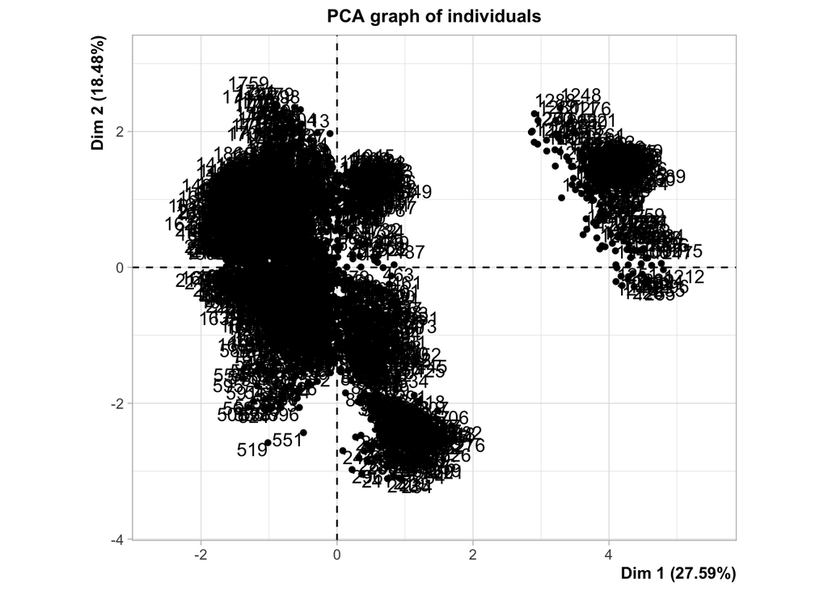

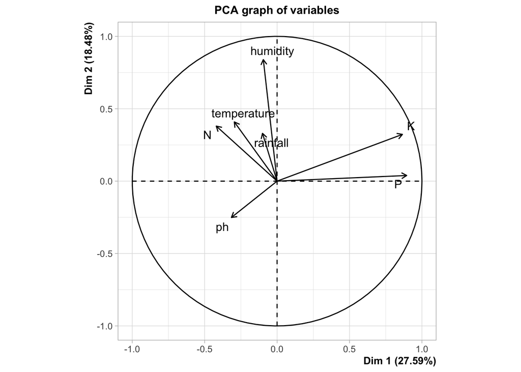

```r
res_HCPC <- HCPC(res_PCA, nb.clust = 3) ## 3 clusters
```

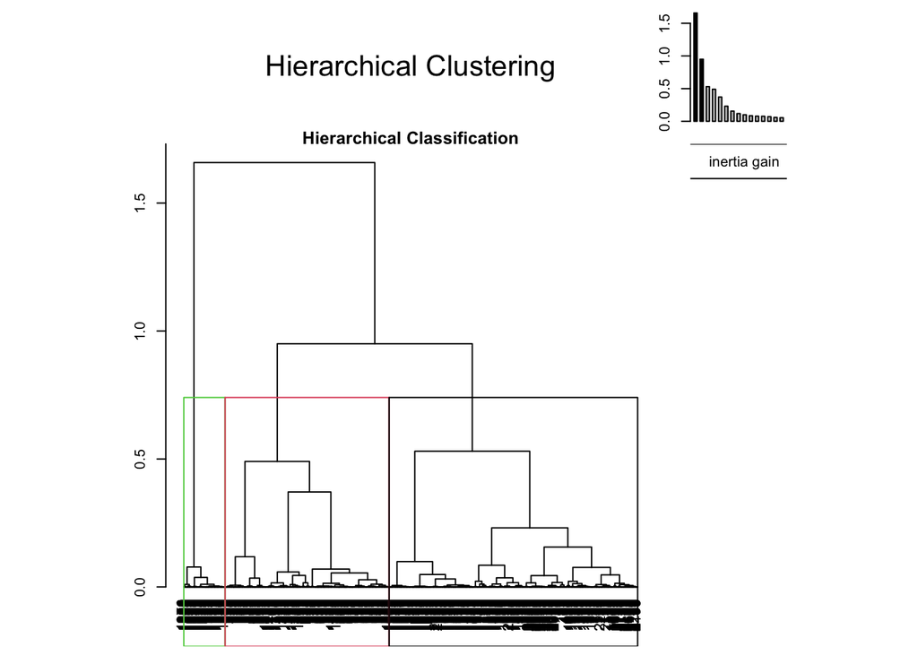

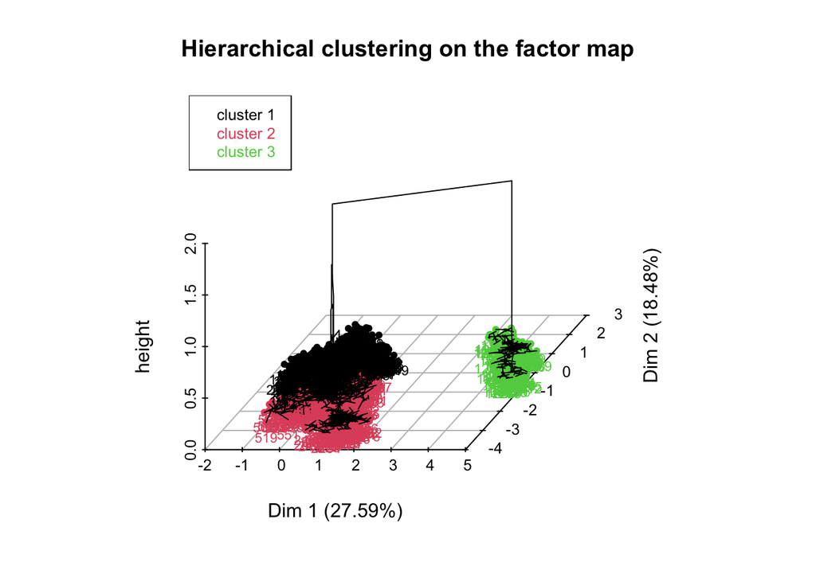

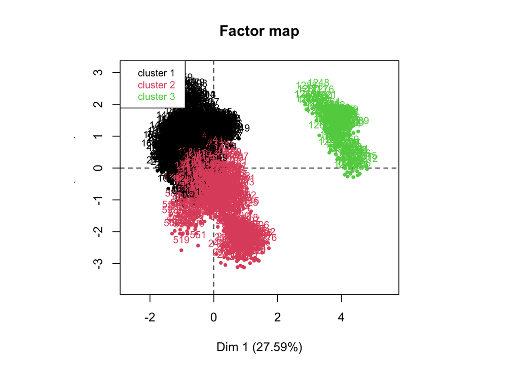

```r
dta2 <- dta
dta2$clust <- res_HCPC$data.clust$clust
table_clusters_label <- table(dta2$label, dta2$clust)
print(table_clusters_label)
```

```
##
##                 1   2   3
##   apple         0   0 100
##   banana      100   0   0
##   blackgram     0 100   0
##   chickpea      0 100   0
##   coconut     100   0   0
##   coffee      100   0   0
##   cotton      100   0   0
##   grapes        0   0 100
##   jute        100   0   0
##   kidneybeans   0 100   0
##   lentil        0 100   0
##   maize        79  21   0
##   mango         0 100   0
##   mothbeans     0 100   0
##   mungbean      5  95   0
##   muskmelon   100   0   0
##   orange       99   1   0
##   papaya       99   1   0
##   pigeonpeas    5  95   0
##   pomegranate  92   8   0
##   rice        100   0   0
##   watermelon  100   0   0
```

```r
## Cluster 1 = Banana, Coconut, Coffee, Cotton, Jute, Maize, Muskmelon, Orange, Papaya, Pomegrade, Rice, Watermelon
## Cluster 2 = Blackgram, Chickpea, Kidneybeans, Lentil, Mango, Mothbeans, Mungbean, Pigeonpeas
## Cluster 3 = Apple, Grapes

res_HCPC$desc.var$quanti$`1`
```

```
##              v.test Mean in category Overall mean sd in category Overall sd
## N         29.896741         72.44953     50.55182     36.1291359 36.9089426
## humidity  26.205040         83.05699     71.48178     11.0149721 22.2587511
## rainfall  16.925562        121.91898    103.46366     62.5047087 54.9458966
## ph         2.459776          6.50725      6.46948      0.5558402  0.7737618
## K        -12.098751         35.99152     48.14909     13.6615430 50.6364183
## P        -24.766596         37.15437     53.36273     21.7610959 32.9783851
##                p.value
## N        2.169424e-196
## humidity 2.328226e-151
## rainfall  2.915491e-64
## ph        1.390239e-02
## K         1.072301e-33
## P        2.054326e-135
```

```r
res_HCPC$desc.var$quanti$`2`
```

```
##                 v.test Mean in category Overall mean sd in category Overall sd
## P             4.152397        57.147381     53.36273      16.370228 32.9783851
## ph            3.064621         6.535016      6.46948       1.037016  0.7737618
## temperature   2.197248        25.923677     25.61624       5.216591  5.0625976
## K           -13.957348        28.616322     48.14909      19.726144 50.6364183
## rainfall    -15.474548        79.964558    103.46366      35.794826 54.9458966
## N           -24.006691        26.063337     50.55182      15.901061 36.9089426
## humidity    -33.207386        51.053423     71.48178      21.843505 22.2587511
##                   p.value
## P            3.290111e-05
## ph           2.179460e-03
## temperature  2.800272e-02
## K            2.837995e-44
## rainfall     5.153361e-54
## N           2.367540e-127
## humidity    8.422269e-242
```

```r
res_HCPC$desc.var$quanti$`3`
```

```
##                 v.test Mean in category Overall mean sd in category Overall sd
## K            44.469990        200.00000     48.14909      3.2787193 50.6364183
## P            35.978234        133.37500     53.36273      7.8895104 32.9783851
## humidity     10.407899         87.10431     71.48178      5.3927887 22.2587511
## rainfall     -3.327766         91.13330    103.46366     22.1914558 54.9458966
## temperature  -6.959578         23.24026     25.61624      6.9033742  5.0625976
## ph           -9.422977          5.97780      6.46948      0.2866251  0.7737618
## N           -11.475374         21.99000     50.55182     12.1663429 36.9089426
##                   p.value
## K            0.000000e+00
## P           1.832097e-283
## humidity     2.282018e-25
## rainfall     8.754532e-04
## temperature  3.412932e-12
## ph           4.384775e-21
## N            1.754169e-30
```

```r
resPCA2 <- PCA(dta[,-9], scale.unit = TRUE, quali.sup = 8)
```

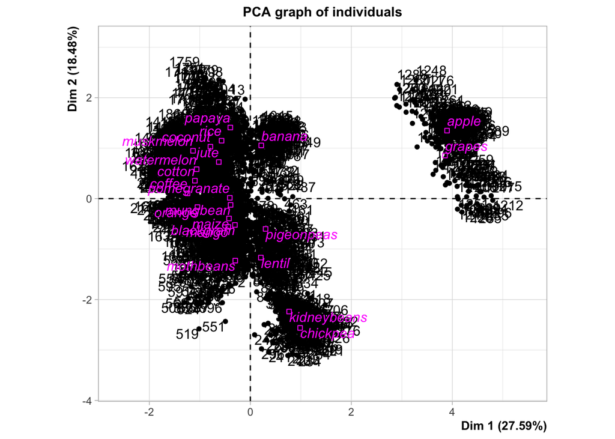

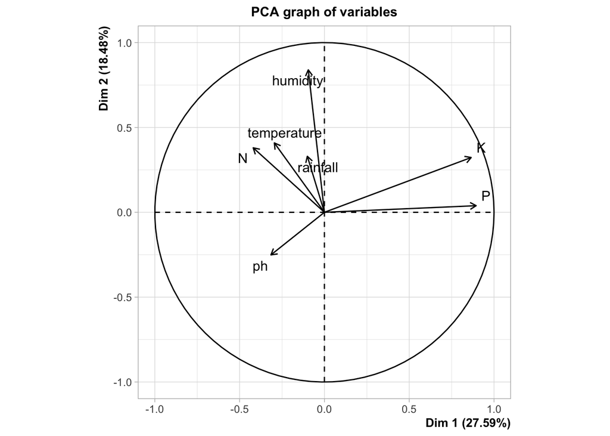

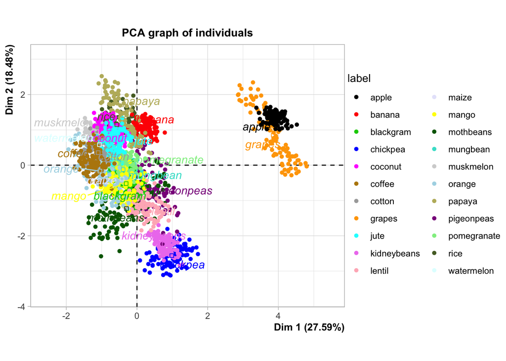

```r
plot(resPCA2,habillage=8,label="quali")
```

Nous obtenons ici trois cluster différents. Le premier cluster inclut les fruits tropicaux et les cultures de rente, tels que la banane, la noix de coco, et le café, qui prospèrent dans des conditions de sol humide, riche en azote, avec des précipitations importantes. Ces cultures sont adaptées à des climats tropicaux où l’abondance d’eau et un sol bien drainé sont essentiels pour une croissance optimale. Le deuxième cluster regroupe la mangue et les légumineuses comme les pois chiches, les haricots mungo. Ces plantes préfèrent un sol relativement pauvre en azote, bien drainé, et faiblement humide. Le dernier cluster comprend des cultures tempérées comme la pomme et le raisin, qui préfèrent un sol riche en potassium et en phosphore, mais pauvre en azote.

## Evaluation des modèles dans le cas d’un sous-ensemble de cultures similaires

Nous avons sélectionné 5 cultures très similaires pour évaluer la capacité de prédiction de nos modèles dans le cas de situations où les cultures présentent des caractéristiques agronomiques et environnementales proches. L’objectif est de vérifier si les modèles peuvent encore discriminer correctement dans des contextes où les variations entre les cultures sont faibles, simulant ainsi des choix agricoles plus délicats à effectuer. Pour ce faire nous avons choisi les cultures suivantes : le jute, le riz, le maïs, le cotton et le café. Ces cultures prospèrent dans les climats tropicaux chauds et humides.

### Modèle de régression logistique

```r
cultures_similaires <- c("coffee", "cotton", "maize", "rice", "jute")

filtered_test_data <- data.test[data.test$label %in% cultures_similaires, ]
filtered_test_data <- droplevels(filtered_test_data)

# Prédiction avec le sous-ensemble de culture
pred_glm_filtered <- predict(glm_model, newdata = filtered_test_data)

# Matrice de confusion et accuracy
pred_glm_filtered <- factor(pred_glm_filtered, levels = levels(filtered_test_data$label))
conf_matrix_filtered <- confusionMatrix(pred_glm_filtered, filtered_test_data$label)
print(conf_matrix_filtered)
```

```
## Confusion Matrix and Statistics
##
##           Reference
## Prediction coffee cotton jute maize rice
##     coffee     25      0    2     0    0
##     cotton      0     21    0    13    0
##     jute        0      0   20     0    8
##     maize       0      0    1     8    0
##     rice        0      0    0     0   15
##
## Overall Statistics
##
##                Accuracy : 0.7876
##                  95% CI : (0.7007, 0.8589)
##     No Information Rate : 0.2212
##     P-Value [Acc > NIR] : < 2.2e-16
##
##                   Kappa : 0.7342
##
##  Mcnemar's Test P-Value : NA
##
## Statistics by Class:
##
##                      Class: coffee Class: cotton Class: jute Class: maize
## Sensitivity                 1.0000        1.0000      0.8696      0.38095
## Specificity                 0.9773        0.8587      0.9111      0.98913
## Pos Pred Value              0.9259        0.6176      0.7143      0.88889
## Neg Pred Value              1.0000        1.0000      0.9647      0.87500
## Prevalence                  0.2212        0.1858      0.2035      0.18584
## Detection Rate              0.2212        0.1858      0.1770      0.07080
## Detection Prevalence        0.2389        0.3009      0.2478      0.07965
## Balanced Accuracy           0.9886        0.9293      0.8903      0.68504
##                      Class: rice
## Sensitivity               0.6522
## Specificity               1.0000
## Pos Pred Value            1.0000
## Neg Pred Value            0.9184
## Prevalence                0.2035
## Detection Rate            0.1327
## Detection Prevalence      0.1327
## Balanced Accuracy         0.8261
```

```r
accuracy_filtered <- conf_matrix_filtered$overall['Accuracy']
```

### Modèle Knn

Nous testons ici le modèle construit à partir des 22 cultures du jeu de données avec le sous-ensemble jute, riz, maïs, cotton et café.

```r
cultures_similaires <- c("coffee", "cotton", "maize", "rice", "jute")

filtered_test_data <- data.test[data.test$label %in% cultures_similaires, ]
filtered_test_data <- droplevels(filtered_test_data)

# Prédiction avec le sous-ensemble de culture
pred_knn_filtered <- predict(knn_model, newdata = filtered_test_data)

# Matrice de confusion et accuracy
pred_knn_filtered <- factor(pred_knn_filtered, levels = levels(filtered_test_data$label))
conf_matrix_filtered <- confusionMatrix(pred_knn_filtered, filtered_test_data$label)
print(conf_matrix_filtered)
```

```
## Confusion Matrix and Statistics
##
##           Reference
## Prediction coffee cotton jute maize rice
##     coffee     24      0    0     0    0
##     cotton      0     25    0     2    0
##     jute        1      0   23     0    4
##     maize       0      0    0    23    0
##     rice        0      0    2     0   21
##
## Overall Statistics
##
##                Accuracy : 0.928
##                  95% CI : (0.8677, 0.9665)
##     No Information Rate : 0.2
##     P-Value [Acc > NIR] : < 2.2e-16
##
##                   Kappa : 0.91
##
##  Mcnemar's Test P-Value : NA
##
## Statistics by Class:
##
##                      Class: coffee Class: cotton Class: jute Class: maize
## Sensitivity                 0.9600        1.0000      0.9200       0.9200
## Specificity                 1.0000        0.9800      0.9500       1.0000
## Pos Pred Value              1.0000        0.9259      0.8214       1.0000
## Neg Pred Value              0.9901        1.0000      0.9794       0.9804
## Prevalence                  0.2000        0.2000      0.2000       0.2000
## Detection Rate              0.1920        0.2000      0.1840       0.1840
## Detection Prevalence        0.1920        0.2160      0.2240       0.1840
## Balanced Accuracy           0.9800        0.9900      0.9350       0.9600
##                      Class: rice
## Sensitivity               0.8400
## Specificity               0.9800
## Pos Pred Value            0.9130
## Neg Pred Value            0.9608
## Prevalence                0.2000
## Detection Rate            0.1680
## Detection Prevalence      0.1840
## Balanced Accuracy         0.9100
```

```r
accuracy_filtered <- conf_matrix_filtered$overall['Accuracy']
```

## Evaluation des modèles dans le cas d’un sous-ensemble de cultures variés

```r
cultures_similaires <- c("banana", "lentil", "apple", "mango", "chickpea")

filtered_test_data <- data.test[data.test$label %in% cultures_similaires, ]
filtered_test_data <- droplevels(filtered_test_data)

# Prédiction avec le sous-ensemble de culture
pred_glm_filtered <- predict(glm_model, newdata = filtered_test_data)

# Matrice de confusion et accuracy
pred_glm_filtered <- factor(pred_glm_filtered, levels = levels(filtered_test_data$label))
conf_matrix_filtered <- confusionMatrix(pred_glm_filtered, filtered_test_data$label)
print(conf_matrix_filtered)
```

```
## Confusion Matrix and Statistics
##
##           Reference
## Prediction apple banana chickpea lentil mango
##   apple       25      0        0      0     0
##   banana       0     25        0      0     0
##   chickpea     0      0       25      0     0
##   lentil       0      0        0     21     0
##   mango        0      0        0      0    23
##
## Overall Statistics
##
##                Accuracy : 1
##                  95% CI : (0.9695, 1)
##     No Information Rate : 0.2101
##     P-Value [Acc > NIR] : < 2.2e-16
##
##                   Kappa : 1
##
##  Mcnemar's Test P-Value : NA
##
## Statistics by Class:
##
##                      Class: apple Class: banana Class: chickpea Class: lentil
## Sensitivity                1.0000        1.0000          1.0000        1.0000
## Specificity                1.0000        1.0000          1.0000        1.0000
## Pos Pred Value             1.0000        1.0000          1.0000        1.0000
## Neg Pred Value             1.0000        1.0000          1.0000        1.0000
## Prevalence                 0.2101        0.2101          0.2101        0.1765
## Detection Rate             0.2101        0.2101          0.2101        0.1765
## Detection Prevalence       0.2101        0.2101          0.2101        0.1765
## Balanced Accuracy          1.0000        1.0000          1.0000        1.0000
##                      Class: mango
## Sensitivity                1.0000
## Specificity                1.0000
## Pos Pred Value             1.0000
## Neg Pred Value             1.0000
## Prevalence                 0.1933
## Detection Rate             0.1933
## Detection Prevalence       0.1933
## Balanced Accuracy          1.0000
```

```r
accuracy_filtered <- conf_matrix_filtered$overall['Accuracy']
```

```r
cultures_similaires <- c("banana", "lentil", "apple", "mango", "chickpea")

filtered_test_data <- data.test[data.test$label %in% cultures_similaires, ]
filtered_test_data <- droplevels(filtered_test_data)

# Prédiction avec le sous-ensemble de culture
pred_knn_filtered <- predict(knn_model, newdata = filtered_test_data)

# Matrice de confusion et accuracy
pred_knn_filtered <- factor(pred_knn_filtered, levels = levels(filtered_test_data$label))
conf_matrix_filtered <- confusionMatrix(pred_knn_filtered, filtered_test_data$label)
print(conf_matrix_filtered)
```

```
## Confusion Matrix and Statistics
##
##           Reference
## Prediction apple banana chickpea lentil mango
##   apple       25      0        0      0     0
##   banana       0     25        0      0     0
##   chickpea     0      0       25      0     0
##   lentil       0      0        0     25     0
##   mango        0      0        0      0    25
##
## Overall Statistics
##
##                Accuracy : 1
##                  95% CI : (0.9709, 1)
##     No Information Rate : 0.2
##     P-Value [Acc > NIR] : < 2.2e-16
##
##                   Kappa : 1
##
##  Mcnemar's Test P-Value : NA
##
## Statistics by Class:
##
##                      Class: apple Class: banana Class: chickpea Class: lentil
## Sensitivity                   1.0           1.0             1.0           1.0
## Specificity                   1.0           1.0             1.0           1.0
## Pos Pred Value                1.0           1.0             1.0           1.0
## Neg Pred Value                1.0           1.0             1.0           1.0
## Prevalence                    0.2           0.2             0.2           0.2
## Detection Rate                0.2           0.2             0.2           0.2
## Detection Prevalence          0.2           0.2             0.2           0.2
## Balanced Accuracy             1.0           1.0             1.0           1.0
##                      Class: mango
## Sensitivity                   1.0
## Specificity                   1.0
## Pos Pred Value                1.0
## Neg Pred Value                1.0
## Prevalence                    0.2
## Detection Rate                0.2
## Detection Prevalence          0.2
## Balanced Accuracy             1.0
```

```r
accuracy_filtered <- conf_matrix_filtered$overall['Accuracy']
```